# Lab 6: Variable Selection and Regularization

Author

Sydney Thompson

Github Link: https://github.com/orsydney003/GSB_S544/tree/main/Lab6

## Dataset: Baseball Players

# In this lab, we will use predictive modeling to design a model that predicts a baseball player’s salary in a given year.

## This dataset was originally taken from the StatLib library which is maintained at Carnegie Mellon University. This is part of the data that was used in the 1988 ASA Graphics Section Poster Session. The salary data were originally from Sports Illustrated, April 20, 1987. The 1986 and career statistics were obtained from The 1987 Baseball Encyclopedia Update published by Collier Books, Macmillan Publishing Company, New York.

## Format: A data frame with 322 observations of major league players on the following 20 variables.

- `AtBat` Number of times at bat in 1986
- `Hits` Number of hits in 1986
- `HmRun` Number of home runs in 1986
- `Runs` Number of runs in 1986
- `RBI` Number of runs batted in in 1986
- `Walks` Number of walks in 1986
- `Years` Number of years in the major leagues
- `CAtBat` Number of times at bat during his career
- `CHits` Number of hits during his career
- `CHmRun` Number of home runs during his career
- `CRuns` Number of runs during his career
- `CRBI` Number of runs batted in during his career
- `CWalks` Number of walks during his career
- `League` A factor with levels A and N indicating player’s league at the end of 1986
- `Division` A factor with levels E and W indicating player’s division at the end of 1986
- `PutOuts` Number of put outs in 1986
- `Assists` Number of assists in 1986
- `Errors` Number of errors in 1986
- `Salary` 1987 annual salary on opening day in thousands of dollars
- `NewLeague` A factor with levels A and N indicating player’s league at the beginning of 1987

## You can download the dataset from here.

## A couple notes about this lab:

## 1. Although it isn’t listed as a specific question, don’t forget to clean your data at the beginning. How will you handle missing data? Are there any variables that need adjusting?

## 2. There are a lot of variables in the dataset! You may want to use the remainder = “passthrough” trick in your column transformers, rather than typing out a ton of gene names.

## 3. Don’t forget that in penalized regression, we must standardize our numeric variables.

## 4. There is a lot of repetition in this lab. Think about ways to streamline your code - for example, you might consider writing simple functions to easily create pipelines.

```python
# import data-set
import numpy as np
import pandas as pd

baseball_data = pd.read_csv("Hitters.csv")
baseball_data
```

|  | AtBat | Hits | HmRun | Runs | RBI | Walks | Years | CAtBat | CHits | CHmRun | CRuns | CRBI | CWalks | League | Division | PutOuts | Assists | Errors | Salary | NewLeague |
| --- | --- | --- | --- | --- | --- | --- | --- | --- | --- | --- | --- | --- | --- | --- | --- | --- | --- | --- | --- | --- |
| 0 | 293 | 66 | 1 | 30 | 29 | 14 | 1 | 293 | 66 | 1 | 30 | 29 | 14 | A | E | 446 | 33 | 20 | NaN | A |
| 1 | 315 | 81 | 7 | 24 | 38 | 39 | 14 | 3449 | 835 | 69 | 321 | 414 | 375 | N | W | 632 | 43 | 10 | 475.0 | N |
| 2 | 479 | 130 | 18 | 66 | 72 | 76 | 3 | 1624 | 457 | 63 | 224 | 266 | 263 | A | W | 880 | 82 | 14 | 480.0 | A |
| 3 | 496 | 141 | 20 | 65 | 78 | 37 | 11 | 5628 | 1575 | 225 | 828 | 838 | 354 | N | E | 200 | 11 | 3 | 500.0 | N |
| 4 | 321 | 87 | 10 | 39 | 42 | 30 | 2 | 396 | 101 | 12 | 48 | 46 | 33 | N | E | 805 | 40 | 4 | 91.5 | N |
| ... | ... | ... | ... | ... | ... | ... | ... | ... | ... | ... | ... | ... | ... | ... | ... | ... | ... | ... | ... | ... |
| 317 | 497 | 127 | 7 | 65 | 48 | 37 | 5 | 2703 | 806 | 32 | 379 | 311 | 138 | N | E | 325 | 9 | 3 | 700.0 | N |
| 318 | 492 | 136 | 5 | 76 | 50 | 94 | 12 | 5511 | 1511 | 39 | 897 | 451 | 875 | A | E | 313 | 381 | 20 | 875.0 | A |
| 319 | 475 | 126 | 3 | 61 | 43 | 52 | 6 | 1700 | 433 | 7 | 217 | 93 | 146 | A | W | 37 | 113 | 7 | 385.0 | A |
| 320 | 573 | 144 | 9 | 85 | 60 | 78 | 8 | 3198 | 857 | 97 | 470 | 420 | 332 | A | E | 1314 | 131 | 12 | 960.0 | A |
| 321 | 631 | 170 | 9 | 77 | 44 | 31 | 11 | 4908 | 1457 | 30 | 775 | 357 | 249 | A | W | 408 | 4 | 3 | 1000.0 | A |

322 rows × 20 columns

```python
# examining the data
baseball_data.info()
```

```
<class 'pandas.core.frame.DataFrame'>
RangeIndex: 322 entries, 0 to 321
Data columns (total 20 columns):
 #   Column     Non-Null Count  Dtype
---  ------     --------------  -----
 0   AtBat      322 non-null    int64
 1   Hits       322 non-null    int64
 2   HmRun      322 non-null    int64
 3   Runs       322 non-null    int64
 4   RBI        322 non-null    int64
 5   Walks      322 non-null    int64
 6   Years      322 non-null    int64
 7   CAtBat     322 non-null    int64
 8   CHits      322 non-null    int64
 9   CHmRun     322 non-null    int64
 10  CRuns      322 non-null    int64
 11  CRBI       322 non-null    int64
 12  CWalks     322 non-null    int64
 13  League     322 non-null    object
 14  Division   322 non-null    object
 15  PutOuts    322 non-null    int64
 16  Assists    322 non-null    int64
 17  Errors     322 non-null    int64
 18  Salary     263 non-null    float64
 19  NewLeague  322 non-null    object
dtypes: float64(1), int64(16), object(3)
memory usage: 50.4+ KB
```

```python
# descriptive statistics
baseball_data.describe()
```

|  | AtBat | Hits | HmRun | Runs | RBI | Walks | Years | CAtBat | CHits | CHmRun | CRuns | CRBI | CWalks | PutOuts | Assists | Errors | Salary |
| --- | --- | --- | --- | --- | --- | --- | --- | --- | --- | --- | --- | --- | --- | --- | --- | --- | --- |
| count | 322.000000 | 322.000000 | 322.000000 | 322.000000 | 322.000000 | 322.000000 | 322.000000 | 322.00000 | 322.000000 | 322.000000 | 322.000000 | 322.000000 | 322.000000 | 322.000000 | 322.000000 | 322.000000 | 263.000000 |
| mean | 380.928571 | 101.024845 | 10.770186 | 50.909938 | 48.027950 | 38.742236 | 7.444099 | 2648.68323 | 717.571429 | 69.490683 | 358.795031 | 330.118012 | 260.239130 | 288.937888 | 106.913043 | 8.040373 | 535.925882 |
| std | 153.404981 | 46.454741 | 8.709037 | 26.024095 | 26.166895 | 21.639327 | 4.926087 | 2324.20587 | 654.472627 | 86.266061 | 334.105886 | 333.219617 | 267.058085 | 280.704614 | 136.854876 | 6.368359 | 451.118681 |
| min | 16.000000 | 1.000000 | 0.000000 | 0.000000 | 0.000000 | 0.000000 | 1.000000 | 19.00000 | 4.000000 | 0.000000 | 1.000000 | 0.000000 | 0.000000 | 0.000000 | 0.000000 | 0.000000 | 67.500000 |
| 25% | 255.250000 | 64.000000 | 4.000000 | 30.250000 | 28.000000 | 22.000000 | 4.000000 | 816.75000 | 209.000000 | 14.000000 | 100.250000 | 88.750000 | 67.250000 | 109.250000 | 7.000000 | 3.000000 | 190.000000 |
| 50% | 379.500000 | 96.000000 | 8.000000 | 48.000000 | 44.000000 | 35.000000 | 6.000000 | 1928.00000 | 508.000000 | 37.500000 | 247.000000 | 220.500000 | 170.500000 | 212.000000 | 39.500000 | 6.000000 | 425.000000 |
| 75% | 512.000000 | 137.000000 | 16.000000 | 69.000000 | 64.750000 | 53.000000 | 11.000000 | 3924.25000 | 1059.250000 | 90.000000 | 526.250000 | 426.250000 | 339.250000 | 325.000000 | 166.000000 | 11.000000 | 750.000000 |
| max | 687.000000 | 238.000000 | 40.000000 | 130.000000 | 121.000000 | 105.000000 | 24.000000 | 14053.00000 | 4256.000000 | 548.000000 | 2165.000000 | 1659.000000 | 1566.000000 | 1378.000000 | 492.000000 | 32.000000 | 2460.000000 |

```python
# removing columns with mostly NaNs
good_cols = baseball_data.isna().sum() < 100
baseball_data = baseball_data.loc[:,good_cols]

# also dropping other NAs
baseball_data = baseball_data.dropna()
```

```python
# dummifying each categorical variable separately

cat_league = pd.get_dummies(baseball_data['League'], prefix='League')
cat_division = pd.get_dummies(baseball_data['Division'], prefix='Division')
cat_newleague = pd.get_dummies(baseball_data['NewLeague'], prefix='newLeague')
```

```python
# concatenating the dataframe to add the dummy variables to the original
baseball_data = pd.concat([baseball_data, cat_division, cat_league, cat_newleague], axis = 1)
baseball_data
```

|  | AtBat | Hits | HmRun | Runs | RBI | Walks | Years | CAtBat | CHits | CHmRun | ... | Assists | Errors | Salary | NewLeague | Division_E | Division_W | League_A | League_N | newLeague_A | newLeague_N |
| --- | --- | --- | --- | --- | --- | --- | --- | --- | --- | --- | --- | --- | --- | --- | --- | --- | --- | --- | --- | --- | --- |
| 1 | 315 | 81 | 7 | 24 | 38 | 39 | 14 | 3449 | 835 | 69 | ... | 43 | 10 | 475.0 | N | False | True | False | True | False | True |
| 2 | 479 | 130 | 18 | 66 | 72 | 76 | 3 | 1624 | 457 | 63 | ... | 82 | 14 | 480.0 | A | False | True | True | False | True | False |
| 3 | 496 | 141 | 20 | 65 | 78 | 37 | 11 | 5628 | 1575 | 225 | ... | 11 | 3 | 500.0 | N | True | False | False | True | False | True |
| 4 | 321 | 87 | 10 | 39 | 42 | 30 | 2 | 396 | 101 | 12 | ... | 40 | 4 | 91.5 | N | True | False | False | True | False | True |
| 5 | 594 | 169 | 4 | 74 | 51 | 35 | 11 | 4408 | 1133 | 19 | ... | 421 | 25 | 750.0 | A | False | True | True | False | True | False |
| ... | ... | ... | ... | ... | ... | ... | ... | ... | ... | ... | ... | ... | ... | ... | ... | ... | ... | ... | ... | ... | ... |
| 317 | 497 | 127 | 7 | 65 | 48 | 37 | 5 | 2703 | 806 | 32 | ... | 9 | 3 | 700.0 | N | True | False | False | True | False | True |
| 318 | 492 | 136 | 5 | 76 | 50 | 94 | 12 | 5511 | 1511 | 39 | ... | 381 | 20 | 875.0 | A | True | False | True | False | True | False |
| 319 | 475 | 126 | 3 | 61 | 43 | 52 | 6 | 1700 | 433 | 7 | ... | 113 | 7 | 385.0 | A | False | True | True | False | True | False |
| 320 | 573 | 144 | 9 | 85 | 60 | 78 | 8 | 3198 | 857 | 97 | ... | 131 | 12 | 960.0 | A | True | False | True | False | True | False |
| 321 | 631 | 170 | 9 | 77 | 44 | 31 | 11 | 4908 | 1457 | 30 | ... | 4 | 3 | 1000.0 | A | False | True | True | False | True | False |

263 rows × 26 columns

```python
# checking to make sure there are no more NAs
baseball_data.isnull().sum()
```

```
AtBat          0
Hits           0
HmRun          0
Runs           0
RBI            0
Walks          0
Years          0
CAtBat         0
CHits          0
CHmRun         0
CRuns          0
CRBI           0
CWalks         0
League         0
Division       0
PutOuts        0
Assists        0
Errors         0
Salary         0
NewLeague      0
Division_E     0
Division_W     0
League_A       0
League_N       0
newLeague_A    0
newLeague_N    0
dtype: int64
```

```python
# shape of dataframe (dimensions)
baseball_data.shape
```

```
(263, 26)
```

## Part I: Different Model Specs

## A. Regression without regularization

## 1. Create a pipeline that includes all the columns as predictors for Salary, and performs ordinary linear regression

```python
from sklearn.pipeline import Pipeline
from sklearn.compose import make_column_selector, ColumnTransformer
from sklearn.preprocessing import StandardScaler, OneHotEncoder, PolynomialFeatures
from sklearn.linear_model import LinearRegression, Ridge, Lasso, ElasticNet
from sklearn.model_selection import train_test_split, cross_val_score
from sklearn.metrics import r2_score
```

```python
baseball_data.columns
```

```
Index(['AtBat', 'Hits', 'HmRun', 'Runs', 'RBI', 'Walks', 'Years', 'CAtBat',
       'CHits', 'CHmRun', 'CRuns', 'CRBI', 'CWalks', 'League', 'Division',
       'PutOuts', 'Assists', 'Errors', 'Salary', 'NewLeague', 'Division_E',
       'Division_W', 'League_A', 'League_N', 'newLeague_A', 'newLeague_N'],
      dtype='object')
```

```python
X = baseball_data.drop('Salary', axis = 1)
y = baseball_data["Salary"]
```

```python
# model 1
# LinearRegression()

ct1 = ColumnTransformer(
  [
    ("dummify",
    OneHotEncoder(sparse_output = False, handle_unknown='ignore'),
    make_column_selector(dtype_include=object)),
    ("standardize",
    StandardScaler(),
    make_column_selector(dtype_include=np.number))
  ],
  remainder = "passthrough"
).set_output(transform="pandas")

ct1.fit(X)

ct1.transform(X)

linear_regression_pipe = Pipeline([
    ('preprocessor', ct1),
    ('linear_regression', LinearRegression())
])
```

## 2. Fit this pipeline to the full dataset, and interpret a few of the most important coefficients.

```python
linear_regression_pipe_fit = linear_regression_pipe.fit(X, y)
linear_regression_pipe_fit
```

```
Pipeline(steps=[('preprocessor',
                 ColumnTransformer(remainder='passthrough',
                                   transformers=[('dummify',
                                                  OneHotEncoder(handle_unknown='ignore',
                                                                sparse_output=False),
                                                  <sklearn.compose._column_transformer.make_column_selector object at 0x000001F948660EC0>),
                                                 ('standardize',
                                                  StandardScaler(),
                                                  <sklearn.compose._column_transformer.make_column_selector object at 0x000001F948620F50>)])),
                ('linear_regression', LinearRegression())])
```

```python
# finding the coefficients of all the variables and sorting

lr_coefficients = linear_regression_pipe_fit.named_steps['linear_regression'].coef_
lr_coefficients_names = linear_regression_pipe_fit.named_steps["preprocessor"].get_feature_names_out()
coefficients_df = pd.DataFrame({"Variable": lr_coefficients_names, "Coef": lr_coefficients})

coefficients_df.sort_values(by = "Coef", ascending=False).head(5)
```

|  | Variable | Coef |
| --- | --- | --- |
| 16 | standardize__CRuns | 480.747135 |
| 7 | standardize__Hits | 337.830479 |
| 17 | standardize__CRBI | 260.689886 |
| 11 | standardize__Walks | 135.073897 |
| 14 | standardize__CHits | 86.687617 |

My top 5 coefficients in this pipeline were `CRuns`, `Hits`, `CRBI`, `Walks`, and `CHits`. These variables are player performance statistics, and they seem to be strong predictors of salary. Baseball players who performed better in 1986 tended to earn higher salaries in 1987 and for their overall careers.

However, we should keep in mind that there may be overfitting because career stats can be highly correlated with each other.

## 3. Use cross-validation to estimate the MSE you would expect if you used this pipeline to predict 1989 salaries.

```python
# cross validation score

mse_scores1 = -cross_val_score(linear_regression_pipe, X, y, scoring = "neg_mean_squared_error", cv = 5)
mse_scores1

mse_scores1.mean()
```

```
np.float64(121136.31031816891)
```

The MSE I would expect if I used this pipeline to predict 1989 salaries is approximately 121,136.31 for a linear regression model.

## B. Ridge regression

## 1. Create a pipeline that includes all the columns as predictors for `Salary`, and performs ordinary ridge regression.

```python
# model 2
# Ridge()

from sklearn.linear_model import Ridge

ridge_pipeline = Pipeline(
  [("preprocessor", ct1),
  ("ridge_regression", Ridge())]
).set_output(transform="pandas")
```

## 2. Use cross-validation to tune the lambda hyperparameter.

```python
# cross validation score
ridge_cv = -cross_val_score(ridge_pipeline, X, y, cv = 5, scoring = 'neg_mean_squared_error')
ridge_cv
```

```
array([ 76993.46940685, 133578.40566044,  78322.08188605, 197323.08126163,
       109813.46171058])
```

```python
ridge_fitted = ridge_pipeline.fit(X, y)
ridge_fitted
```

```
Pipeline(steps=[('preprocessor',
                 ColumnTransformer(remainder='passthrough',
                                   transformers=[('dummify',
                                                  OneHotEncoder(handle_unknown='ignore',
                                                                sparse_output=False),
                                                  <sklearn.compose._column_transformer.make_column_selector object at 0x000001F948660EC0>),
                                                 ('standardize',
                                                  StandardScaler(),
                                                  <sklearn.compose._column_transformer.make_column_selector object at 0x000001F948620F50>)])),
                ('ridge_regression', Ridge())])
```

```python
from sklearn.model_selection import GridSearchCV

alphas = {'ridge_regression__alpha': np.array([1000, 100, 10, 1, 0.1, 0.01])}
gscv = GridSearchCV(ridge_pipeline, param_grid=alphas, cv = 5, scoring='neg_mean_squared_error')
```

```python
gscv_fitted = gscv.fit(X, y)

ridge_results = pd.DataFrame(gscv_fitted.cv_results_)
ridge_results

print("Best Alpha For Ridge Regression", gscv_fitted.best_params_)
```

```
Best Alpha For Ridge Regression {'ridge_regression__alpha': np.float64(1.0)}
```

The best alpha (lambda) for ridge regression is 1.

## 3. Fit the pipeline with your chosen lambda to the full dataset, and interpret a few of the most important coefficients.

```python
alpha_ridge_pipe = Pipeline(
  [("preprocessor", ct1),
  ("ridge_regression", Ridge(alpha = 1))]
)

alpha_ridge_pipe.fit(X, y)

# finding the coefficients and sorting
coefficients_ridge = alpha_ridge_pipe.named_steps['ridge_regression'].coef_
ridge_coef_names = alpha_ridge_pipe.named_steps["preprocessor"].get_feature_names_out()
ridge_coef_df = pd.DataFrame({"Variable": ridge_coef_names, "Coef": coefficients_ridge})

ridge_coef_df.sort_values(by = "Coef", ascending=False).head(5)
```

|  | Variable | Coef |
| --- | --- | --- |
| 16 | standardize__CRuns | 320.210650 |
| 7 | standardize__Hits | 296.562127 |
| 17 | standardize__CRBI | 160.370155 |
| 14 | standardize__CHits | 126.899495 |
| 11 | standardize__Walks | 124.440241 |

My top 5 coefficients were `CRuns`, `Hits`, `CRBI`, `CHits`, and `Walks`. The ridge pipeline produced similar predictors; however, we can see that the coefficients are much smaller. The shrinkage shows the reduction in variability, which stabilizes the model.

## 4. Report the MSE you would expect if you used this pipeline to predict 1989 salaries.

```python
gscv_fitted = gscv.fit(X, y)

gscv_fitted.cv_results_
print("Estimated MSE for Ridge Pipeline", -gscv_fitted.best_score_)
```

```
Estimated MSE for Ridge Pipeline 119206.09998510798
```

The MSE I would expect from this ridge pipeline to predict 1989 salaries is approximately 119,206.10.

## C. Lasso Regression

## 1. Create a pipeline that includes all the columns as predictors for `Salary`, and performs ordinary lasso regression.

```python
# model 3
# Lasso()
# was getting convergent warnings, so I added the max_iter parameter
# this removed them

from sklearn.linear_model import Lasso

lasso_pipeline = Pipeline(
  [("preprocessor", ct1),
  ("lasso_regression", Lasso(max_iter=10000))]
).set_output(transform="pandas")
```

```python
lasso_fitted = lasso_pipeline.fit(X, y)
lasso_fitted
```

```
Pipeline(steps=[('preprocessor',
                 ColumnTransformer(remainder='passthrough',
                                   transformers=[('dummify',
                                                  OneHotEncoder(handle_unknown='ignore',
                                                                sparse_output=False),
                                                  <sklearn.compose._column_transformer.make_column_selector object at 0x000001F948660EC0>),
                                                 ('standardize',
                                                  StandardScaler(),
                                                  <sklearn.compose._column_transformer.make_column_selector object at 0x000001F948620F50>)])),
                ('lasso_regression', Lasso(max_iter=10000))])
```

## 2. Use cross-validation to tune the lambda hyperparameter.

```python
lasso_cv = -cross_val_score(lasso_pipeline, X, y, cv = 5, scoring = "neg_mean_squared_error")
lasso_cv
```

```
array([ 75612.34953401, 135042.27981274,  79230.77710798, 198771.18156354,
       110133.57020794])
```

```python
alphas = {'lasso_regression__alpha': np.array([1000, 100, 10, 1, 0.1, 0.01])}
gscv_lasso = GridSearchCV(lasso_pipeline, param_grid=alphas, cv = 5, scoring='neg_mean_squared_error')
```

```python
gscv_fitted_lasso = gscv_lasso.fit(X, y)

gscv_fitted_lasso.cv_results_

lasso_fitted_df = pd.DataFrame(gscv_fitted_lasso.cv_results_)
lasso_fitted_df

print("Best Alpha Parameter For Lasso", gscv_fitted_lasso.best_params_)
```

```
Best Alpha Parameter For Lasso {'lasso_regression__alpha': np.float64(1.0)}
```

The best alpha parameter for the Lasso pipeline is 1.

## 3. Fit the pipeline with your chosen lambda to the full dataset, and interpret a few of the most important coefficients.

```python
alpha_lasso_pipe = Pipeline(
  [("preprocessor", ct1),
  ("lasso_regression", Lasso(alpha = 1))]
)

alpha_lasso_pipe.fit(X, y)

# finding the coefficients and sorting
coefficients_lasso = alpha_lasso_pipe.named_steps['lasso_regression'].coef_
lasso_coef_names = alpha_lasso_pipe.named_steps["preprocessor"].get_feature_names_out()
lasso_coef_df = pd.DataFrame({"Variable": lasso_coef_names, "Coef": coefficients_lasso})

lasso_coef_df.sort_values(by = "Coef", ascending=False).head(5)
```

|  | Variable | Coef |
| --- | --- | --- |
| 16 | standardize__CRuns | 375.565510 |
| 7 | standardize__Hits | 304.359499 |
| 17 | standardize__CRBI | 192.610931 |
| 11 | standardize__Walks | 120.695271 |
| 2 | dummify__Division_E | 113.481995 |

My top 5 coefficients are `CRuns`, `Hits`, `CRBI`, `Walks`, and `Division_E`. With the Lasso model, we see that this pipeline shrinks and eliminates some of the coefficients from the model. In this case, it set the weaker predictors to zero, and still focuses on similar player performance variables from above.

This pipeline simplifies the model drastically. The MSE is slightly higher than the Ridge MSE; however, it doesn’t mean it is more accurate in predicting salary.

## 4. Report the MSE you would expect if you used this pipeline to predict 1989 salaries.

```python
print("MSE for Lasso Pipeline", -gscv_fitted_lasso.best_score_)
```

```
MSE for Lasso Pipeline 119758.03164524357
```

The MSE I would expect if I used this pipeline to predict 1989 salaries is approximately 119,758.03.

## D. Elastic Net

## 1. Create a pipeline that includes all the columns as predictors for Salary, and performs ordinary elastic net regression.

```python
# model 4
# ElasticNet()

from sklearn.linear_model import ElasticNet

elastic_net_pipeline = Pipeline(
  [("preprocessor", ct1),
  ("elastic_net", ElasticNet(max_iter=1000000))]
).set_output(transform="pandas")
```

## 2. Use cross-validation to tune the lambda and alpha hyperparameters.

```python
elastic_net_cv = -cross_val_score(elastic_net_pipeline, X, y, cv = 5, scoring ='neg_mean_squared_error')
elastic_net_cv
```

```
array([ 55567.47486474, 168570.20408645,  94144.08367153, 186288.73255675,
        97859.20839506])
```

```python
elastic_fitted = elastic_net_pipeline.fit(X, y)
elastic_fitted
```

```
Pipeline(steps=[('preprocessor',
                 ColumnTransformer(remainder='passthrough',
                                   transformers=[('dummify',
                                                  OneHotEncoder(handle_unknown='ignore',
                                                                sparse_output=False),
                                                  <sklearn.compose._column_transformer.make_column_selector object at 0x000001F948660EC0>),
                                                 ('standardize',
                                                  StandardScaler(),
                                                  <sklearn.compose._column_transformer.make_column_selector object at 0x000001F948620F50>)])),
                ('elastic_net', ElasticNet(max_iter=1000000))])
```

```python
param_grid = {
    "elastic_net__alpha": [1, 10, 100, 1000],
    "elastic_net__l1_ratio": np.arange(0.0, 1.2, 0.2),
}

gscv_elastic_net = GridSearchCV(elastic_net_pipeline, param_grid=param_grid, cv = 5, scoring='neg_mean_squared_error')
```

```python
gscv_fitted_elnet = gscv_elastic_net.fit(X, y)

print("Best Alpha and L1 for Elastic Net", gscv_fitted_elnet.best_params_)

df_cv_results_ = pd.DataFrame(gscv_fitted_elnet.cv_results_)
```

[output not shown]

[output cut: 24 more lines]

[output not shown]

```
Best Alpha and L1 for Elastic Net {'elastic_net__alpha': 1, 'elastic_net__l1_ratio': np.float64(1.0)}
```

The best alpha for the elastic net pipeline is 1. The best l1_ratio for the elastic net pipeline is 1.0.

## 3. Fit the pipeline with your chosen hyperparameters to the full dataset, and interpret a few of the most important coefficients.

```python
alpha_enet_pipe= Pipeline(
  [("preprocessor", ct1),
  ("elastic_net", ElasticNet(alpha = 1, l1_ratio=1.0, max_iter=100000))]
)

alpha_enet_pipe.fit(X, y)

# finding the coefficients and sorting
coefficients_elnet = alpha_enet_pipe.named_steps['elastic_net'].coef_
elnet_coef_names = alpha_enet_pipe.named_steps["preprocessor"].get_feature_names_out()
elnet_coef_df = pd.DataFrame({"Variable": elnet_coef_names, "Coef": coefficients_elnet})

elnet_coef_df.sort_values(by = "Coef", ascending=False).head(5)
```

|  | Variable | Coef |
| --- | --- | --- |
| 16 | standardize__CRuns | 375.565510 |
| 7 | standardize__Hits | 304.359499 |
| 17 | standardize__CRBI | 192.610931 |
| 11 | standardize__Walks | 120.695271 |
| 2 | dummify__Division_E | 113.481995 |

This pipeline had a similar MSE to the Lasso pipeline. It seems like many of the predictors are highly correlated. Therefore, this helped stabilize variable selection.

## 4. Report the MSE you would expect if you used this pipeline to predict 1989 salaries.

```python
print("MSE for Elastic Net Pipeline", -gscv_fitted_elnet.best_score_)
```

```
MSE for Elastic Net Pipeline 119758.03164524357
```

## Part II. Variable Selection

Based on the above results, decide on:

- Which numeric variable is most important.
- Which five numeric variables are most important
- Which categorical variable is most important

For each of the four model specifications, compare the following possible feature sets:

1. Using only the one best numeric variable.
2. Using only the five best variables.
3. Using the five best numeric variables and their interactions with the one best categorical variable.

Report which combination of features and model performed best, based on the validation metric of MSE.

(Note: lambda and alpha must be re-tuned for each feature set.)

## Based on results above:

```python
# best numerical variable
best_num_1 = "CRuns"

# best categorical variable
best_cat = "Division"
```

```python
# linear coefficients (from part 1) -> finding absolute values
coefficients_df["abs_coef"] = coefficients_df["Coef"].abs()
coefficients_df.sort_values(by="abs_coef", ascending=False).head(10)
```

|  | Variable | Coef | abs_coef |
| --- | --- | --- | --- |
| 16 | standardize__CRuns | 480.747135 | 480.747135 |
| 13 | standardize__CAtBat | -391.038655 | 391.038655 |
| 7 | standardize__Hits | 337.830479 | 337.830479 |
| 6 | standardize__AtBat | -291.094556 | 291.094556 |
| 17 | standardize__CRBI | 260.689886 | 260.689886 |
| 18 | standardize__CWalks | -213.892259 | 213.892259 |
| 11 | standardize__Walks | 135.073897 | 135.073897 |
| 14 | standardize__CHits | 86.687617 | 86.687617 |
| 19 | standardize__PutOuts | 78.761296 | 78.761296 |
| 9 | standardize__Runs | -60.572479 | 60.572479 |

From looking at the dataframe, the best numerical variable is CRuns. The best 5 variables are CRuns, CAtBat, Hits, AtBat, and CRBI. The best categorical variable is Division.

```python
# best 5 linear variables
best_linear_5 = ["CRuns","CAtBat","Hits","AtBat","CRBI"]
```

```python
# ridge coefficients from part 1 -> finding absolute values
ridge_coef_df["abs_coef"] = ridge_coef_df["Coef"].abs()
ridge_coef_df.sort_values(by="abs_coef", ascending=False).head(10)
```

|  | Variable | Coef | abs_coef |
| --- | --- | --- | --- |
| 16 | standardize__CRuns | 320.210650 | 320.210650 |
| 7 | standardize__Hits | 296.562127 | 296.562127 |
| 6 | standardize__AtBat | -270.475963 | 270.475963 |
| 13 | standardize__CAtBat | -225.356448 | 225.356448 |
| 18 | standardize__CWalks | -184.494218 | 184.494218 |
| 17 | standardize__CRBI | 160.370155 | 160.370155 |
| 14 | standardize__CHits | 126.899495 | 126.899495 |
| 11 | standardize__Walks | 124.440241 | 124.440241 |
| 19 | standardize__PutOuts | 78.609529 | 78.609529 |
| 20 | standardize__Assists | 47.446480 | 47.446480 |

From the dataframe above, the best ridge numerical variable is CRuns. The best 5 numerical variables are CRuns, Hits, AtBat, CAtBat, and CWalks. The best categorical variable is Division.

```python
# best ridge variables
best_ridge_5 = ["CRuns","Hits","AtBat","CAtBat","CWalks"]
```

```python
# lasso coefficients from part 1 -> finding absolute values
lasso_coef_df["abs_coef"] = lasso_coef_df["Coef"].abs()
lasso_coef_df.sort_values(by="abs_coef", ascending=False).head(10)
```

|  | Variable | Coef | abs_coef |
| --- | --- | --- | --- |
| 16 | standardize__CRuns | 375.565510 | 375.565510 |
| 7 | standardize__Hits | 304.359499 | 304.359499 |
| 6 | standardize__AtBat | -282.370947 | 282.370947 |
| 17 | standardize__CRBI | 192.610931 | 192.610931 |
| 18 | standardize__CWalks | -189.644630 | 189.644630 |
| 13 | standardize__CAtBat | -162.639819 | 162.639819 |
| 11 | standardize__Walks | 120.695271 | 120.695271 |
| 2 | dummify__Division_E | 113.481995 | 113.481995 |
| 19 | standardize__PutOuts | 78.760365 | 78.760365 |
| 20 | standardize__Assists | 41.996679 | 41.996679 |

From looking at the dataframe, the best numerical variable is CRuns. The best 5 variables are CRuns, Hits, AtBat, CRBI, and CWalks. The best categorical variable is Division.

```python
# best 5 lasso variables
best_lasso_5 = ["CRuns","Hits","AtBat","CRBI","CWalks"]
```

```python
# elastic net coefficients from part 1 -> finding absolute values
elnet_coef_df["abs_coef"] = elnet_coef_df["Coef"].abs()
elnet_coef_df.sort_values(by="abs_coef", ascending=False).head(10)
```

|  | Variable | Coef | abs_coef |
| --- | --- | --- | --- |
| 16 | standardize__CRuns | 375.565510 | 375.565510 |
| 7 | standardize__Hits | 304.359499 | 304.359499 |
| 6 | standardize__AtBat | -282.370947 | 282.370947 |
| 17 | standardize__CRBI | 192.610931 | 192.610931 |
| 18 | standardize__CWalks | -189.644630 | 189.644630 |
| 13 | standardize__CAtBat | -162.639819 | 162.639819 |
| 11 | standardize__Walks | 120.695271 | 120.695271 |
| 2 | dummify__Division_E | 113.481995 | 113.481995 |
| 19 | standardize__PutOuts | 78.760365 | 78.760365 |
| 20 | standardize__Assists | 41.996679 | 41.996679 |

From looking at the dataframe, the best numerical variable is CRuns. The best 5 variables are CRuns, Hits, AtBat, CRBI, and CWalks. The best categorical variable is Division.

```python
# best 5 elastic net variables
best_elnet_5 = ["CRuns","Hits","AtBat","CRBI","CWalks"]
```

```python
# for tuning alphas and l1_ratio (for elastic net)

alphas = [0.001, 0.01, 0.1, 1, 10, 100, 300, 1000]
enet_grid = {
    "elastic_net__alpha": [0.001, 0.01, 0.1, 1, 10, 100],
    "elastic_net__l1_ratio": [0.1, 0.3, 0.5, 0.7, 0.9, 1.0]
}
```

## Set 1: Using only the one best numeric variable

```python
# column transformer for set 1

ct_best_num = ColumnTransformer(
    transformers=[
        ("standardize", StandardScaler(), [best_num_1]),

    ],
    remainder="drop"
)
```

```python
# linear regression pipeline

best_num_linear_pipe = Pipeline([
    ("preprocessor", ct_best_num),
    ("linear_regression", LinearRegression())
])

mse_best_num_linear = -cross_val_score(best_num_linear_pipe, X, y, scoring="neg_mean_squared_error", cv=5).mean()
print("MSE For Linear Pipeline", mse_best_num_linear)
```

```
MSE For Linear Pipeline 143812.9359162973
```

The MSE for the linear regression pipeline using only the best numerical variable is approximately 143,812.94.

```python
# ridge pipeline
best_num_ridge_pipe = Pipeline([
    ("preprocessor", ct_best_num),
    ("ridge", Ridge())
])

gscv_best_num_ridge = GridSearchCV(best_num_ridge_pipe, param_grid={"ridge__alpha": alphas}, scoring="neg_mean_squared_error", cv=5)

gscv_best_num_ridge.fit(X, y)

print("Best alpha for Ridge:", gscv_best_num_ridge.best_params_["ridge__alpha"])
print("MSE for Ridge:", -gscv_best_num_ridge.best_score_)
```

```
Best alpha for Ridge: 10
MSE for Ridge: 143658.5173685888
```

The best alpha for the ridge regression is 10. The MSE for this ridge regression is approximately 143,658.52.

```python
# lasso pipeline
# used max_iter again to remove convergent warnings

pipe_best_num_lasso = Pipeline([
    ("preprocessor", ct_best_num),
    ("lasso", Lasso(max_iter=10000))
])

gscv_best_num_lasso = GridSearchCV(pipe_best_num_lasso, param_grid={"lasso__alpha": alphas}, scoring="neg_mean_squared_error", cv=5)
gscv_best_num_lasso.fit(X, y)

print("Best Lasso alpha", gscv_best_num_lasso.best_params_["lasso__alpha"])
print("MSE for Lasso regression", -gscv_best_num_lasso.best_score_)
```

```
Best Lasso alpha 10
MSE for Lasso regression 143793.4491585397
```

The best alpha for the lasso regression is 10. The MSE for this lasso regression is approximately 143,793.45.

```python
# elastic net pipeline
# using max_iter for removing convergent warnings

pipe_best_num_enet = Pipeline([
    ("preprocessor", ct_best_num),
    ("elastic_net", ElasticNet(max_iter=10000))
])

gscv_best_num_enet = GridSearchCV(pipe_best_num_enet, param_grid=enet_grid, scoring="neg_mean_squared_error", cv=5)
gscv_best_num_enet.fit(X, y)

print("Best Elastic Net parameters", gscv_best_num_enet.best_params_)
print("MSE for Elastic Net regression", -gscv_best_num_enet.best_score_)
```

```
Best Elastic Net parameters {'elastic_net__alpha': 0.1, 'elastic_net__l1_ratio': 0.5}
MSE for Elastic Net regression 143655.07604766646
```

The best alpha for the elastic net regression is 0.1, and the best l1_ratio is 0.5. The MSE for this pipeline is approximately 143,655.08.

## Set 2: Using only the five best variables

```python
ct_best5_linear = ColumnTransformer(
    transformers=[
        ("standardize", StandardScaler(), best_linear_5),
    ],
    remainder="drop"
)

pipe_best5_linear = Pipeline([
    ("preprocessor", ct_best5_linear),
    ("linear_regression", LinearRegression())
])

mse_best5_linear = -cross_val_score(pipe_best5_linear, X, y, scoring="neg_mean_squared_error", cv=5).mean()
print("MSE for Linear Regression", mse_best5_linear)
```

```
MSE for Linear Regression 121228.21777043605
```

The MSE for this linear regression pipeline is approximately 121,228.22.

```python
# ridge pipeline with 5 best numerical variables
# new column transformer

ct_best5_ridge = ColumnTransformer(
    transformers=[
        ("standardize", StandardScaler(), best_ridge_5),
    ],
    remainder="drop"
)

pipe_best5_ridge = Pipeline([
    ("preprocessor", ct_best5_ridge),
    ("ridge", Ridge())
])

gscv_best5_ridge = GridSearchCV(pipe_best5_ridge, param_grid={"ridge__alpha": alphas}, scoring="neg_mean_squared_error", cv=5)
gscv_best5_ridge.fit(X, y)

print("Best Ridge alpha:", gscv_best5_ridge.best_params_["ridge__alpha"])
print("MSE:", -gscv_best5_ridge.best_score_)
```

```
Best Ridge alpha: 1
MSE: 126800.37050367214
```

The best alpha for the ridge pipeline using the 5 best numerical variables is 1. The MSE for this pipeline is approximately 126,800.37.

```python
# lasso pipeline with 5 best numerical variables
# new column transformer

ct_best5_lasso = ColumnTransformer(
    transformers=[
        ("standardize", StandardScaler(), best_lasso_5),
    ],
    remainder="drop"
)

pipe_best5_lasso = Pipeline([
    ("preprocessor", ct_best5_lasso),
    ("lasso", Lasso(max_iter=10000))
])

gscv_best5_lasso = GridSearchCV(pipe_best5_lasso, param_grid={"lasso__alpha": alphas}, scoring="neg_mean_squared_error", cv=5)
gscv_best5_lasso.fit(X, y)

print("Best Lasso alpha:", gscv_best5_lasso.best_params_["lasso__alpha"])
print("MSE:", -gscv_best5_lasso.best_score_)
```

```
Best Lasso alpha: 1
MSE: 125289.76033255174
```

The best alpha for the lasso pipeline using the 5 best numerical variables is 1. The MSE for this pipeline is approximately 125,289.76.

```python
# elastic net pipeline using the 5 best numerical variables
# new column transformer

ct_best5_elnet = ColumnTransformer(
    transformers=[
        ("standardize", StandardScaler(), best_elnet_5),
    ],
    remainder="drop"
)

pipe_best5_elnet = Pipeline([
    ("preprocessor", ct_best5_elnet),
    ("elastic_net", ElasticNet(max_iter=10000))
])

gscv_best5_elnet = GridSearchCV(pipe_best5_elnet, param_grid=enet_grid, scoring="neg_mean_squared_error", cv=5)
gscv_best5_elnet.fit(X, y)

print("Best Elastic Net parameters:", gscv_best5_elnet.best_params_)
print("MSE:", -gscv_best5_elnet.best_score_)
```

```
Best Elastic Net parameters: {'elastic_net__alpha': 0.1, 'elastic_net__l1_ratio': 0.9}
MSE: 124989.38152900881
```

The best alpha for the elastic net pipeline using the 5 best numerical variables is 0.1; the best l1_ratio is 0.9. The MSE for this pipeline is approximately 124,989.38.

## Set 3: Using the five best numeric variables and their interactions with the one best categorical variable

```python
ct_best5_cat_linear = ColumnTransformer(
    transformers=[
        ("standardize", StandardScaler(), best_linear_5),
        ("dummify", OneHotEncoder(handle_unknown = "ignore", sparse_output=False), [best_cat])
    ],
    remainder="drop"
)

pipe_best5_cat_linear = Pipeline([
    ("preprocessor", ct_best5_cat_linear),
    ("poly", PolynomialFeatures(degree = 2, interaction_only=True, include_bias=False)),
    ("linear", LinearRegression())
])

mse_best5_cat_linear = -cross_val_score(pipe_best5_cat_linear, X, y, scoring="neg_mean_squared_error", cv=5).mean()
print("Linear MSE:", mse_best5_cat_linear)
```

```
Linear MSE: 170576.70468557702
```

The MSE for this linear regression is approximately 170,576.70.

```python
# ridge pipeline with interactions as well
# creating new column transformer too

ct_best5_cat_ridge = ColumnTransformer(
    transformers=[
        ("standardize", StandardScaler(), best_ridge_5),
        ("dummify", OneHotEncoder(handle_unknown = "ignore", sparse_output=False), [best_cat])
    ],
    remainder="drop"
)

pipe_best5_cat_ridge = Pipeline([
    ("preprocessor", ct_best5_cat_ridge),
    ("poly", PolynomialFeatures(degree = 2, interaction_only=True, include_bias=False)),
    ("ridge", Ridge())
])

gscv_best5_cat_ridge = GridSearchCV(pipe_best5_cat_ridge, param_grid={"ridge__alpha": alphas}, scoring="neg_mean_squared_error", cv=5)
gscv_best5_cat_ridge.fit(X, y)

print("Ridge Best alpha:", gscv_best5_cat_ridge.best_params_["ridge__alpha"])
print("Ridge MSE:", -gscv_best5_cat_ridge.best_score_)
```

```
Ridge Best alpha: 300
Ridge MSE: 113101.66868292207
```

The best alpha for the ridge regression is 300. The MSE for this ridge pipeline is approximately 113,101.67.

```python
# lasso pipeline with interactions as well
# creating new column transformer too

ct_best5_cat_lasso = ColumnTransformer(
    transformers=[
        ("standardize", StandardScaler(), best_lasso_5),
        ("dummify", OneHotEncoder(handle_unknown = "ignore", sparse_output=False), [best_cat])
    ],
    remainder="drop"
)

pipe_best5_cat_lasso = Pipeline([
    ("preprocessor", ct_best5_cat_lasso),
    ("poly", PolynomialFeatures(degree = 2, interaction_only=True, include_bias=False)),
    ("lasso", Lasso(max_iter=10000000))
])

gscv_best5_cat_lasso = GridSearchCV(pipe_best5_cat_lasso, param_grid={"lasso__alpha": alphas}, scoring="neg_mean_squared_error", cv=5)
gscv_best5_cat_lasso.fit(X, y)

print("Lasso best alpha:", gscv_best5_cat_lasso.best_params_["lasso__alpha"])
print("Lasso MSE:", -gscv_best5_cat_lasso.best_score_)
```

```
Lasso best alpha: 10
Lasso MSE: 126993.72436034742
```

The best alpha for the lasso pipeline is 10. The MSE for this pipeline is approximately 126,993.72.

```python
# elastic net pipeline with interactions as well
# creating new column transformer too

ct_best5_cat_elnet = ColumnTransformer(
    transformers=[
        ("standardize", StandardScaler(), best_elnet_5),
        ("dummify", OneHotEncoder(handle_unknown = "ignore", sparse_output=False), [best_cat])
    ],
    remainder="drop"
)

pipe_best5_cat_elnet = Pipeline([
    ("preprocessor", ct_best5_cat_elnet),
    ("poly", PolynomialFeatures(degree = 2, interaction_only=True, include_bias=False)),
    ("elastic_net", ElasticNet(max_iter=10000000))
])

gscv_best5_cat_elnet = GridSearchCV(pipe_best5_cat_elnet, param_grid=enet_grid, scoring="neg_mean_squared_error", cv=5)
gscv_best5_cat_elnet.fit(X, y)

print("Elastic Net best parameters:", gscv_best5_cat_elnet.best_params_)
print("Elastic Net MSE:", -gscv_best5_cat_elnet.best_score_)
```

```
Elastic Net best parameters: {'elastic_net__alpha': 1, 'elastic_net__l1_ratio': 0.3}
Elastic Net MSE: 105057.4746735293
```

The best alpha for the elastic net pipeline is 1. Its best l1_ratio is 0.3. Finally, the MSE for this pipeline is approximately 105,057.47.

After running all the models, my best model is the Elastic Net with the 5 best numerical variables and interaction with the categorical variable `Division`. Its MSE is the lowest by far (105,057.47).

## Part III. Discussion

## A. Ridge

## Compare your Ridge models with your ordinary regression models. How did your coefficients compare? Why does this make sense?

In Ridge regression, we modify the OLS model by adding a penalty term that shrinks the regression coefficients toward zero. This penalty limits how flexible the model can be. In my results, the Ridge coefficients were smaller than those from the standard linear regression. There is a tradeoff with increasing the bias and decreasing variance.

Ridge regression helps prevent overfitting, especially when predictors are correlated. The lambda controls how strong the shrinkage is. If it is equal to 0, there is no penalty. If lambda is large, lambda over-shrinks, which results in underfitting the model.

## B. LASSO

## Compare your LASSO model in I with your three LASSO models in II. Did you get the same results? Why does this make sense? Did you get the same MSEs? Why does this make sense?

Lasso regression works similarly to Ridge; however, it uses the absolute values of the coefficients in its penalty instead of the squares. As a result, some coefficients are exactly zero. This effectively removes those predictors from the model.

This makes sense because Lasso simplifies the model by only focusing on the most important predictors.

## C. Elastic Net

## Compare your MSEs for the Elastic Net models with those for the Ridge and LASSO models. Why does it make sense that Elastic Net always “wins”?

Elastic Net combines both Ridge and Lasso penalties in a single model. The alpha parameter controls the overall regularization, and l1_ratio determines the balance between Ridge- and Lasso-type penalties.

The balance of the two penalties explain why Elastic Net often “wins.” This is because it has the best trade-off between bias and variance. In addition, it stabilizes the coefficients the best, which will give better predictions.

## Part IV: Final Model

## Fit your final best pipeline on the full dataset, and summarize your results in a few short sentences and a plot.

```python
# use the tuned winner from your grid search
best_pipeline = gscv_best5_cat_elnet.best_estimator_

best_cv_mse = -gscv_best5_cat_elnet.best_score_
best_params = gscv_best5_cat_elnet.best_params_

# fit on full data
best_pipeline.fit(X, y)

print("Best pipeline:", best_pipeline)
print("Best MSE:", best_cv_mse)
print("Best parameters:", best_params)
```

```
Best pipeline: Pipeline(steps=[('preprocessor',
                 ColumnTransformer(transformers=[('standardize',
                                                  StandardScaler(),
                                                  ['CRuns', 'Hits', 'AtBat',
                                                   'CRBI', 'CWalks']),
                                                 ('dummify',
                                                  OneHotEncoder(handle_unknown='ignore',
                                                                sparse_output=False),
                                                  ['Division'])])),
                ('poly',
                 PolynomialFeatures(include_bias=False, interaction_only=True)),
                ('elastic_net',
                 ElasticNet(alpha=1, l1_ratio=0.3, max_iter=10000000))])
Best MSE: 105057.4746735293
Best parameters: {'elastic_net__alpha': 1, 'elastic_net__l1_ratio': 0.3}
```

```python
# based on the best pipeline,
# want to compare the actual vs. predicted salaries
y_pred = best_pipeline.predict(X)
prediction_df = pd.DataFrame({"Actual": y, "Predicted": y_pred})
prediction_df["Residual"] = prediction_df["Actual"] - prediction_df["Predicted"]
```

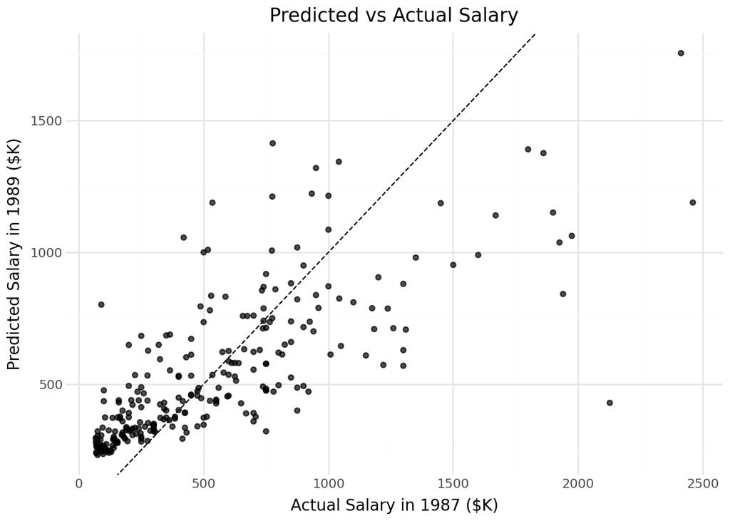

```python
from plotnine import *

# Predicted vs. Actual Salaries
pred_plot = (
    ggplot(prediction_df, aes("Actual", "Predicted"))
    + geom_point(alpha=0.7)
    + geom_abline(slope=1, intercept=0, linetype="dashed")
    + labs(title="Predicted vs Actual Salary",
           x="Actual Salary in 1987 ($K)",
           y="Predicted Salary in 1989 ($K)")
    + theme_minimal()
)
pred_plot
```

The best alpha for the elastic net pipeline is 1. Its best l1_ratio is 0.3.